# SiMBA Demonstration

# Aims

Here I will show the basic usage of SiMBA on a simulated dataset. I will first go through the data briefly, and then demonstrate fitting the model to this data.

# Libraries

```r
library(tidyverse)
library(rstan)
library(brms)
library(skimr)

theme_set(theme_light())
set.seed(555)
```

# Exploring the data

## Loading

I saved the simulated sample data in the RawData folder.

```r
simdat <- readRDS("../RawData/simdata.rds")

head(simdat)
```

| n | Regions | Difference | sigma | Region | logK1_true | logBPnd_true | logVnd_true | logk4_true | logvB_true | sigma_true | inpshift_mod | A | B | C | alpha | beta | gamma | peaktime | peakval | t0 | slope | t_tac | durations | meanblood | sigwig | TAC | sigma_w_true | TAC_true | WAYID | … |
| --- | --- | --- | --- | --- | --- | --- | --- | --- | --- | --- | --- | --- | --- | --- | --- | --- | --- | --- | --- | --- | --- | --- | --- | --- | --- | --- | --- | --- | --- | --- |
| 10 | all | 0.182 | 10% | dor | -2.14728 | 2.040876 | -0.8231854 | -3.666544 | -3.518643 | -3.391607 | 0.01115423 | 181.6999 | 1.348521 | 0.037839 | 4.902644 | 0.3670342 | 0.02419838 | 1.177854 | 3.608804 | 0.324694 | 4.229925 | 0.16667 | 0.33333 | 0.0000000 | 0.7977002 | -0.02622032 | -2.593907 | 0.00000000 | 1 | … |
| 10 | all | 0.182 | 10% | dor | -2.14728 | 2.040876 | -0.8231854 | -3.666544 | -3.518643 | -3.391607 | 0.01115423 | 181.6999 | 1.348521 | 0.037839 | 4.902644 | 0.3670342 | 0.02419838 | 1.177854 | 3.608804 | 0.324694 | 4.229925 | 0.50000 | 0.33333 | 0.6310248 | 0.7540168 | 0.02850400 | -2.637590 | 0.02595788 | 1 | … |
| 10 | all | 0.182 | 10% | dor | -2.14728 | 2.040876 | -0.8231854 | -3.666544 | -3.518643 | -3.391607 | 0.01115423 | 181.6999 | 1.348521 | 0.037839 | 4.902644 | 0.3670342 | 0.02419838 | 1.177854 | 3.608804 | 0.324694 | 4.229925 | 0.83333 | 0.33333 | 2.6889425 | 0.7103335 | 0.14091504 | -2.681273 | 0.13907418 | 1 | … |
| 10 | all | 0.182 | 10% | dor | -2.14728 | 2.040876 | -0.8231854 | -3.666544 | -3.518643 | -3.391607 | 0.01115423 | 181.6999 | 1.348521 | 0.037839 | 4.902644 | 0.3670342 | 0.02419838 | 1.177854 | 3.608804 | 0.324694 | 4.229925 | 1.50000 | 1.00000 | 2.0213709 | 0.6234815 | 0.41909213 | -2.768125 | 0.29228269 | 1 | … |
| 10 | all | 0.182 | 10% | dor | -2.14728 | 2.040876 | -0.8231854 | -3.666544 | -3.518643 | -3.391607 | 0.01115423 | 181.6999 | 1.348521 | 0.037839 | 4.902644 | 0.3670342 | 0.02419838 | 1.177854 | 3.608804 | 0.324694 | 4.229925 | 2.50000 | 1.00000 | 0.9368015 | 0.4954552 | 0.30573178 | -2.896152 | 0.30243776 | 1 | … |
| 10 | all | 0.182 | 10% | dor | -2.14728 | 2.040876 | -0.8231854 | -3.666544 | -3.518643 | -3.391607 | 0.01115423 | 181.6999 | 1.348521 | 0.037839 | 4.902644 | 0.3670342 | 0.02419838 | 1.177854 | 3.608804 | 0.324694 | 4.229925 | 3.50000 | 1.00000 | 0.9125220 | 0.3728948 | 0.31820929 | -3.018712 | 0.31057001 | 1 | … |

```r
skim(simdat)
```

```
── Data Summary ────────────────────────
                           Values
Name                       simdat
Number of rows             3600
Number of columns          31
_______________________
Column type frequency:
  character                4
  numeric                  27
________________________
Group variables            None

── Variable type: character ──────────────────────────────────────────────────────────────────────────────────────────────────────────────────────────────────────────────────────────────
  skim_variable n_missing complete_rate   min   max empty n_unique whitespace
1 Regions               0             1     3     3     0        1          0
2 sigma                 0             1     3     3     0        1          0
3 Region                0             1     3    15     0        9          0
4 Group                 0             1     7     7     0        2          0

── Variable type: numeric ────────────────────────────────────────────────────────────────────────────────────────────────────────────────────────────────────────────────────────────────
   skim_variable n_missing complete_rate     mean       sd       p0     p25     p50     p75     p100 hist
 1 n                     0             1 10        0       10       10      10      10       10      ▁▁▇▁▁
 2 Difference            0             1  0.182    0        0.182    0.182   0.182   0.182    0.182  ▁▁▇▁▁
 3 logK1_true            0             1 -2.47     0.305   -3.35    -2.70   -2.45   -2.25    -1.88   ▁▃▆▇▃
 4 logBPnd_true          0             1  1.99     0.388    1.26     1.64    2.00    2.27     2.97   ▆▆▇▅▁
 5 logVnd_true           0             1 -0.591    0.443   -1.71    -0.803  -0.593  -0.286    0.404  ▂▂▇▆▂
 6 logk4_true            0             1 -3.82     0.200   -4.46    -3.96   -3.77   -3.67    -3.34   ▁▃▅▇▁
 7 logvB_true            0             1 -3.81     0.710   -5.56    -4.29   -3.78   -3.46    -2.10   ▁▅▇▃▂
 8 sigma_true            0             1 -4.23     0.568   -5.53    -4.62   -4.26   -3.85    -2.40   ▂▇▇▂▁
 9 inpshift_mod          0             1 -0.0892   0.127   -0.239   -0.175  -0.105  -0.0661   0.351  ▇▇▂▁▁
10 A                     0             1 27.7     40.3      0.188    4.23   13.4    29.0    182.     ▇▂▁▁▁
11 B                     0             1  1.08     0.441    0.296    0.735   1.14    1.32     1.92   ▆▆▇▆▅
12 C                     0             1  0.0350   0.0201   0.00693  0.0170  0.0293  0.0519   0.0663 ▇▅▁▃▆
13 alpha                 0             1  2.80     1.19     0.489    2.10    3.06    3.42     4.90   ▆▃▇▇▆
14 beta                  0             1  0.481    0.143    0.172    0.387   0.496   0.583    0.717  ▂▃▇▇▅
15 gamma                 0             1  0.0313   0.00957  0.0150   0.0230  0.0358  0.0391   0.0434 ▆▁▂▆▇
16 peaktime              0             1  1.06     0.175    0.825    0.940   1.06    1.13     1.57   ▆▇▃▁▁
17 peakval               0             1  2.53     0.951    0.800    1.92    2.27    3.26     4.58   ▃▇▅▆▁
18 t0                    0             1  0.339    0.150    0.0529   0.272   0.330   0.443    0.755  ▅▅▇▁▁
19 slope                 0             1  3.89     1.78     0.850    2.74    3.69    5.22     7.93   ▅▇▅▇▁
20 t_tac                 0             1 32.4     34.5      0.167    3.31   15.1    57.7    105.     ▇▂▂▂▂
21 durations             0             1  5.50     4.25     0.333    1       5      10       10      ▇▁▂▁▇
22 meanblood             0             1  0.409    0.579    0        0.0520  0.183   0.546    4.32   ▇▁▁▁▁
23 sigwig                0             1  0.00366  0.474   -0.621   -0.423  -0.0587  0.396    0.798  ▇▅▃▃▅
24 TAC                   0             1  0.131    0.0889  -0.287    0.0694  0.122   0.185    0.582  ▁▂▇▂▁
25 sigma_w_true          0             1 -4.23     0.740   -6.15    -4.76   -4.26   -3.72    -1.61   ▂▇▇▃▁
26 TAC_true              0             1  0.131    0.0855   0        0.0677  0.121   0.184    0.588  ▇▆▂▁▁
27 WAYID                 0             1 10.5      5.77     1        5.75   10.5    15.2     20      ▇▇▇▇▇
```

## Measured Data

This dataset consists of 10 controls and 10 patients. The sigma value is set to about 10% of the mean TAC value. There is a group difference of 20% (Cohen’s d = 0.55) in all regions. The unique identifier for each individual is called `WAYID`.

### TAC

```r
subjdat <- simdat %>%
  filter(WAYID==WAYID[sample(1:nrow(simdat), 1)] & Region=="dor")
```

Let’s have a look

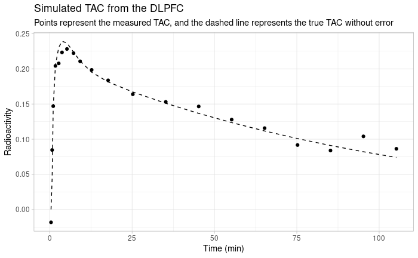

```r
subjdat %>%
  select(t_tac, Measured = TAC, True = TAC_true) %>%
  ggplot(aes(x=t_tac, y=Measured)) +
  geom_point() +
  geom_line(aes(y=True), linetype="dashed") +
  labs(title="Simulated TAC from the DLPFC",
       subtitle="Points represent the measured TAC, and the dashed line represents the true TAC without error",
       x = "Time (min)",
       y = "Radioactivity")
```

### Blood function

The AIF is modelled with a tri-exponential function.

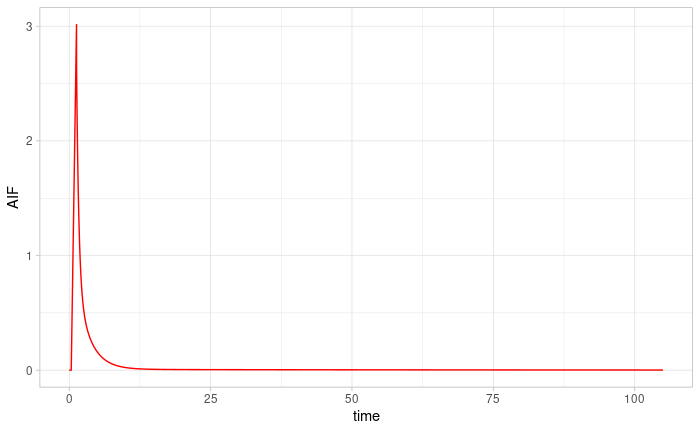

```r
predict_aif <- function(time, t0, slope, peaktime, A, B, C, alpha, beta, gamma) {

  t_corr <- time - t0
  t_after_peak <- time - peaktime

  if(t_corr <= 0) {
    pred <- 0
    return(pred)
  }

  if(t_corr <= peaktime) {
    pred <- t_corr * slope
    return(pred)
  }

  if(t_corr > peaktime) {
    pred <- A*exp(-alpha*t_after_peak) +
      B*exp(-beta*t_after_peak) +
      C*exp(-gamma*t_after_peak)
    return(pred)
  }
}

time <- seq(0, 105, by=0.01)
aif <- map_dbl(time, ~with(subjdat[1,],
            predict_aif(.x, t0, slope, peaktime, A, B, C, alpha, beta, gamma)))

AIFdat <- tibble(
  time = time,
  AIF = aif
)

ggplot(AIFdat, aes(x=time, y=AIF)) +
  geom_line(colour="red")
```

So now, if we show the AIF and the TAC together

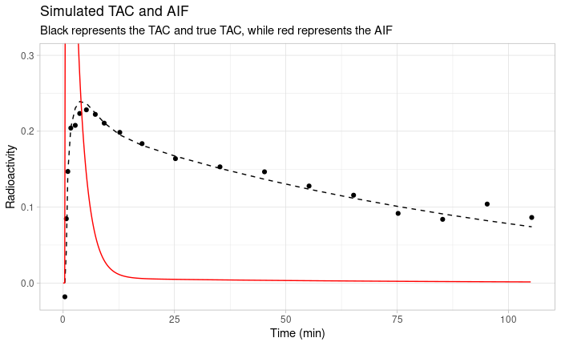

## Simulation Data

Now, let’s explore some of the characteristics of the simulation.

### Measurement Error

First, let’s look at measurement error. This is simulated from the fitted spline. Let’s examine the values of the measurement error SD over the course of the single TAC above.

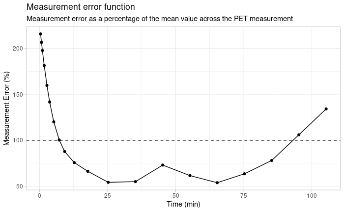

This function is partially related to the durations of the frames, but not completely.

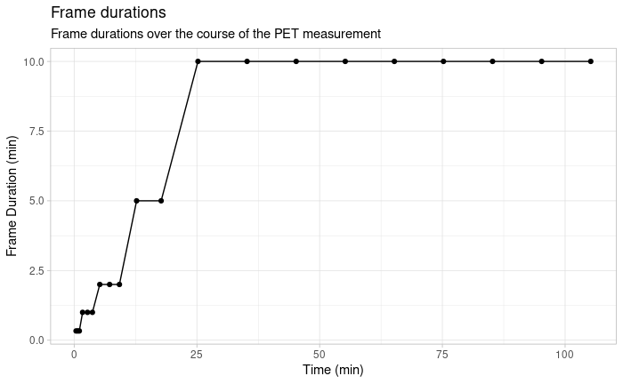

The true sigma at each point in time is taken from the addition of the true sigma for each ROI and individual, `sigma_true`, and adding `sigwig` (the sigma wiggly function), to make `sigma_w_true`.

Let’s show this represented around the TAC.

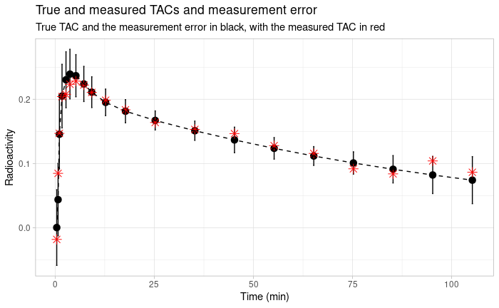

### Parameters by Region

The true parameters are included as simulated from the model. Here I’ll make a data frame with only the parameters.

Let’s look at the differences between true parameters in the different regions.

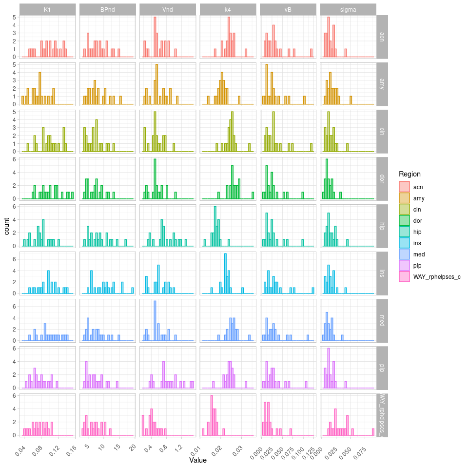

Note the regions are as follows:

- acn : anterior cingulate cortex
- amy : amygdala
- cin : posterior cingulate cortex
- dor : dorsolateral prefrontal cortex
- hip : hippocampus
- ins : insula
- med : medial prefrontal cortex
- pip : parahippocampal cortex
- WAY_rphelpscs_c : dorsal raphe nucleus

### Parameters by Group

There are only group differences in BPnd, which are the same across all regions: 20%. Let’s take a look by looking at only the DLPFC ROI.

```r
parroidat <- pardat %>%
  filter(Region=="dor")
```

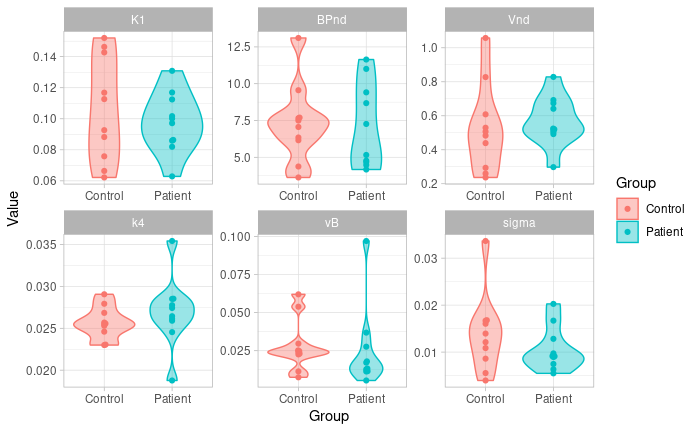

```r
ggplot(parroidat, aes(x=Group, y=Value, colour=Group, fill=Group)) +
  geom_violin(alpha=0.4) +
  geom_beeswarm() +
  facet_wrap(~Parameter, scales="free")
```

This really speaks to the difficulty of sampling variation… Really hard to see anything at all there in BPnd in this particular sample.

# SiMBA

Now, we would like to run SiMBA on this data. We can generate the first version of the STAN code using `brms`.

## Preparation with brms

### Function

First, the 2TC function

```r
two_compartment_log_stan <- "
      real twotcm_log_stan(real logK1, real logVnd, real logBPnd,
                          real logk4, real logvB, real time,
                          real t0_aif, real b_aif, real lambda1_aif,
                          real lambda2_aif, real lambda3_aif,
                          real A1_aif, real A2_aif, real A3_aif,
                          real tstar_aif, real bloodval) {

          real K1;
          real k2;
          real k3;
          real k4;
          real Vnd;
          real BPnd;
          real vB;

          real R1;
          real R2;
          real L1;
          real L2;

          int indicatort0;
          int indicatorpeak;

          real timesincet0;
          real tstaraftert0;

          real pred;

          indicatort0 = time > t0_aif;
          indicatorpeak = time > tstar_aif;



          K1 = exp(logK1);
          Vnd = exp(logVnd);
          BPnd = exp(logBPnd);
          k4 = exp(logk4);
          vB = exp(logvB);

          k2 = K1 / Vnd;
          k3 = k4 * BPnd;

          R1 = 0.5 * (k2 + k3 + k4 + sqrt((k2 + k3 + k4)^2 - 4 * k2 * k4));
          R2 = 0.5 * (k2 + k3 + k4 - sqrt((k2 + k3 + k4)^2 - 4 * k2 * k4));

          L1 = (K1 * (R1 - k3 - k4))/(R1 - R2);
          L2 = (K1 * (k3 + k4 - R2))/(R1 - R2);

          timesincet0 = time - t0_aif;
          tstaraftert0 = tstar_aif - t0_aif;

        pred =  (indicatort0)*((1-vB)*  // whole thing is zero, if before t0

             ((-1*(indicatorpeak-1))*(b_aif*L1*(exp(-R1*timesincet0)/R1^2 + timesincet0/R1 - 1/R1^2) +
             b_aif*L2*(exp(-R2*timesincet0)/R2^2 + timesincet0/R2 - 1/R2^2)) +

             (indicatorpeak)*(b_aif*L1*exp(-R1*timesincet0)*(tstaraftert0/R1*exp(R1*tstaraftert0) -
             1/R1^2*exp(R1*tstaraftert0) +
             1/R1^2) +
             L1*A1_aif*(exp(-lambda1_aif*timesincet0)/(R1-lambda1_aif) -
             exp(R1*tstaraftert0-R1*timesincet0-lambda1_aif*tstaraftert0)/(R1-lambda1_aif)) +
             L1*A2_aif*(exp(-lambda2_aif*timesincet0)/(R1-lambda2_aif) -
             exp(R1*tstaraftert0-R1*timesincet0-lambda2_aif*tstaraftert0)/(R1-lambda2_aif)) +
             L1*A3_aif*(exp(-lambda3_aif*timesincet0)/(R1-lambda3_aif) -
             exp(R1*tstaraftert0-R1*timesincet0-lambda3_aif*tstaraftert0)/(R1-lambda3_aif)) +
             b_aif*L2*exp(-R2*timesincet0)*(tstaraftert0/R2*exp(R2*tstaraftert0) -
             1/R2^2*exp(R2*tstaraftert0) + 1/R2^2) +
             L2*A1_aif*(exp(-lambda1_aif*timesincet0)/(R2-lambda1_aif) -
             exp(R2*tstaraftert0-R2*timesincet0-lambda1_aif*tstaraftert0)/(R2-lambda1_aif)) +
             L2*A2_aif*(exp(-lambda2_aif*timesincet0)/(R2-lambda2_aif) -
             exp(R2*tstaraftert0-R2*timesincet0-lambda2_aif*tstaraftert0)/(R2-lambda2_aif)) +
             L2*A3_aif*(exp(-lambda3_aif*timesincet0)/(R2-lambda3_aif) -
             exp(R2*tstaraftert0-R2*timesincet0-lambda3_aif*tstaraftert0)/(R2-lambda3_aif)))) +

             vB*bloodval);

        return(pred);
      }
      "
```

### Formula

```r
twotcm_formula <- bf( TAC ~ twotcm_log_stan(logK1, logVnd, logBPnd, logk4,
                                                  logvB, t_tac,
                                                  t0, slope,
                                                  alpha, beta, gamma,
                                                  A, B, C, peaktime,
                                                  meanblood),
                            lf(sigma ~ 1 + s(t_tac) + (1 | Region) +
                                 (1 | WAYID), center = FALSE),
                            # Nonlinear variables
                            logK1 ~ 1 + Region + (1|k|WAYID) +
                              (1|l|WAYID:Region),
                            logBPnd ~  1 + Region + Group + (1|k|WAYID) +
                              (1|l|WAYID:Region),
                            logVnd ~ 1 + (1|m|Region) + (1|k|WAYID) +
                              (1|l|WAYID:Region),
                            logk4 ~ 1 + (1|m|Region) + (1|k|WAYID) +
                              (1|l|WAYID:Region),
                            logvB ~ 1 + (1|WAYID) + (1|Region),
                            # Nonlinear fit
                            nl = TRUE, center = TRUE)
```

### Prior

This first requires making sure that the dummy variables work correctly. We’ll make Region into a factor.

```r
simdat <- simdat %>%
  mutate(Region = fct_inorder(Region))
```

```r
twotcm_prior <- c(
  set_prior("normal(-2.5, 0.25)", nlpar = "logK1"),
  set_prior("normal(-1, 0.25)", nlpar = "logVnd"),
  set_prior("normal( 2, 0.25)", nlpar = "logBPnd"),
  set_prior("normal(-4, 0.25)", nlpar = "logk4"),
  set_prior("normal(-4, 0.5)", nlpar = "logvB"),

  set_prior("normal(0, 0.3)", nlpar = "logK1", class = "sd", group="WAYID"),
  set_prior("normal(0, 0.3)", nlpar = "logVnd", class = "sd", group="WAYID"),
  set_prior("normal(0, 0.3)", nlpar = "logBPnd", class = "sd", group="WAYID"),
  set_prior("normal(0, 0.3)", nlpar = "logk4", class = "sd", group="WAYID"),
  set_prior("normal(0, 0.5)", nlpar = "logvB", class = "sd", group="WAYID"),

  set_prior("normal(0, 0.025)", nlpar = "logK1", class = "sd", group="WAYID:Region"),
  set_prior("normal(0, 0.025)", nlpar = "logVnd", class = "sd", group="WAYID:Region"),
  set_prior("normal(0, 0.025)", nlpar = "logBPnd", class = "sd", group="WAYID:Region"),
  set_prior("normal(0, 0.025)", nlpar = "logk4", class = "sd", group="WAYID:Region"),

  set_prior("normal(0, 0.1)", nlpar = "logVnd", class = "sd", group="Region"),
  set_prior("normal(0, 0.1)", nlpar = "logk4", class = "sd", group="Region"),
  set_prior("normal(0, 0.1)", nlpar = "logvB", class = "sd", group="Region"),

  set_prior("normal(0, 0.3)", coef="Regionacn", nlpar="logK1"),
  set_prior("normal(0, 0.3)", coef="Regionamy", nlpar="logK1"),
  set_prior("normal(0, 0.3)", coef="Regioncin", nlpar="logK1"),
  set_prior("normal(0, 0.3)", coef="Regionhip", nlpar="logK1"),
  set_prior("normal(0, 0.3)", coef="Regionins", nlpar="logK1"),
  set_prior("normal(0, 0.3)", coef="Regionmed", nlpar="logK1"),
  set_prior("normal(0, 0.3)", coef="Regionpip", nlpar="logK1"),
  set_prior("normal(0, 0.3)", coef="RegionWAY_rphelpscs_c", nlpar="logK1"),

  set_prior("normal(0, 0.3)", coef="Regionacn", nlpar="logBPnd"),
  set_prior("normal(0, 0.3)", coef="Regionamy", nlpar="logBPnd"),
  set_prior("normal(0, 0.3)", coef="Regioncin", nlpar="logBPnd"),
  set_prior("normal(0, 0.3)", coef="Regionhip", nlpar="logBPnd"),
  set_prior("normal(0, 0.3)", coef="Regionins", nlpar="logBPnd"),
  set_prior("normal(0, 0.3)", coef="Regionmed", nlpar="logBPnd"),
  set_prior("normal(0, 0.3)", coef="Regionpip", nlpar="logBPnd"),
  set_prior("normal(0, 0.3)", coef="RegionWAY_rphelpscs_c",
            nlpar="logBPnd"),

  set_prior("normal(0, 0.2)", coef="GroupPatient",
            nlpar="logBPnd"),

  set_prior("normal(-5, 1)", dpar = "sigma"),
  set_prior("normal(0, 0.3)", dpar = "sigma", class="sd", group="WAYID"),
  set_prior("normal(0, 0.5)", dpar = "sigma", class="sd", group="Region"),

  set_prior("student_t(3, 0, 4)", coef="st_tac_1", dpar = "sigma", class="b"),
  set_prior("student_t(3, 0, 2.5)", dpar = "sigma", class="sds"),

  set_prior("lkj(1)", class="cor", group = "WAYID"),
  set_prior("lkj(2)", class="cor", group = "Region"),
  set_prior("lkj(2)", class="cor", group = "WAYID:Region"))
```

### Fitting with `brms`

Now, at this point, we could run the model with `brms` as follows:

```r
fit <- brm(
    twotcm_formula,
    family=gaussian(),
    data = simdat,
    prior = twotcm_prior,
    stanvars = stanvar(scode = two_compartment_log_stan,
               block="functions"),
    backend = "cmdstanr",
    inits = 0,
    iter = 1000, warmup = 300,
    chains=3, cores=3)
```

However, in order to improve posterior geometry, it is preferable to centre some of the hierarchies. Then we can run the code using `rstan` or `cmdstanr`. I do this by saving the generated STAN code and and manually adjusting it.

### Saving and modifying the brms-generated STAN code

```r
sc
```

```
// generated with brms 2.15.0
functions {
 /* compute correlated group-level effects
  * Args:
  *   z: matrix of unscaled group-level effects
  *   SD: vector of standard deviation parameters
  *   L: cholesky factor correlation matrix
  * Returns:
  *   matrix of scaled group-level effects
  */
  matrix scale_r_cor(matrix z, vector SD, matrix L) {
    // r is stored in another dimension order than z
    return transpose(diag_pre_multiply(SD, L) * z);
  }

      real twotcm_log_stan(real logK1, real logVnd, real logBPnd,
                          real logk4, real logvB, real time,
                          real t0_aif, real b_aif, real lambda1_aif,
                          real lambda2_aif, real lambda3_aif,
                          real A1_aif, real A2_aif, real A3_aif,
                          real tstar_aif, real bloodval) {

          real K1;
          real k2;
          real k3;
          real k4;
          real Vnd;
          real BPnd;
          real vB;

          real R1;
          real R2;
          real L1;
          real L2;

          int indicatort0;
          int indicatorpeak;

          real timesincet0;
          real tstaraftert0;
```

[output cut: 341 more lines]

```
    }
  }
  // extract upper diagonal of correlation matrix
  for (k in 1:M_4) {
    for (j in 1:(k - 1)) {
      cor_4[choose(k - 1, 2) + j] = Cor_4[j, k];
    }
  }
  // extract upper diagonal of correlation matrix
  for (k in 1:M_5) {
    for (j in 1:(k - 1)) {
      cor_5[choose(k - 1, 2) + j] = Cor_5[j, k];
    }
  }
}
```

I’ve saved a modified version of the STAN code with several variables centred.

```r
writeLines(readLines("stancode_mod.stan"))
```

```
// generated with brms 2.14.4
functions {
  /* turn a vector into a matrix of defined dimension
   * stores elements in row major order
   * Args:
   *   X: a vector
   *   N: first dimension of the desired matrix
   *   K: second dimension of the desired matrix
   * Returns:
   *   a matrix of dimension N x K
   */
  matrix as_matrix(vector X, int N, int K) {
    matrix[N, K] Y;
    for (i in 1:N) {
      Y[i] = to_row_vector(X[((i - 1) * K + 1):(i * K)]);
    }
    return Y;
  }
 /* compute correlated group-level effects
  * Args:
  *   z: matrix of unscaled group-level effects
  *   SD: vector of standard deviation parameters
  *   L: cholesky factor correlation matrix
  * Returns:
  *   matrix of scaled group-level effects
  */
  matrix scale_r_cor(matrix z, vector SD, matrix L) {
    // r is stored in another dimension order than z
    return transpose(diag_pre_multiply(SD, L) * z);
  }


real twotcm_log_stan(real logK1, real logVnd, real logBPnd,
                    real logk4, real logvB, real time,
                    real t0_aif, real b_aif, real lambda1_aif,
                    real lambda2_aif, real lambda3_aif,
                    real A1_aif, real A2_aif, real A3_aif,
                    real tstar_aif, real bloodval) {

    real K1;
```

[output cut: 390 more lines]

```
    }
  }
  // extract upper diagonal of correlation matrix
  for (k in 1:M_4) {
    for (j in 1:(k - 1)) {
      cor_4[choose(k - 1, 2) + j] = Cor_4[j, k];
    }
  }
  // extract upper diagonal of correlation matrix
  for (k in 1:M_5) {
    for (j in 1:(k - 1)) {
      cor_5[choose(k - 1, 2) + j] = Cor_5[j, k];
    }
  }
}
```

### Saving and modifying the brms-generated STAN data

We can also save the prepared data

```r
stand <- brms::make_standata(twotcm_formula,
                             data = simdata,
                             family=gaussian(),
                             prior = twotcm_prior)
```

[output not shown]

## Fitting directly

Now we can pass these to `rstan` or `cmdstanr` directly. If we use `cmdstanr`, as I do here, then it is preferable to save it directly to an `rstan` object afterwards. I run it as a job here so that it can process in the background.

```r
job::job({

  mod <- cmdstanr::cmdstan_model(stan_file = "stancode_mod.stan")

  stanfit_cmd <- mod$sample(
    data = stand_list,
    chains = 3,
    parallel_chains = 3,
    adapt_delta=0.8,
    iter_warmup = 300,
    iter_sampling = 700,
    init = 0,
    refresh=10,
  )

  stanfit <- rstan::read_stan_csv(stanfit_cmd$output_files())

  saveRDS(stanfit, "../DerivedData/simdat_simbafit.rds")

})
```

Now we have fitted the model. Unfortunately `rstan` does not present its output in a particularly attractive manner.

```r
stanfit <- readRDS("../DerivedData/simdat_simbafit.rds")

stanfit
```

```
Inference for Stan model: simstan_stan_ncp64-202103220415-1-00a2ac.
3 chains, each with iter=1000; warmup=300; thin=1;
post-warmup draws per chain=700, total post-warmup draws=2100.

                                                         mean se_mean    sd    2.5%     25%     50%     75%   97.5% n_eff Rhat
b_logK1_Intercept                                       -2.26    0.00  0.08   -2.41   -2.31   -2.26   -2.21   -2.11   288 1.00
b_logK1_Regionmed                                        0.00    0.00  0.03   -0.07   -0.03    0.00    0.02    0.06   998 1.00
b_logK1_Regionhip                                       -0.21    0.00  0.04   -0.28   -0.23   -0.21   -0.18   -0.14   767 1.00
b_logK1_Regionamy                                       -0.32    0.00  0.04   -0.40   -0.35   -0.32   -0.30   -0.25   874 1.00
b_logK1_Regionpip                                       -0.25    0.00  0.03   -0.31   -0.27   -0.25   -0.23   -0.19   787 1.00
b_logK1_Regionins                                       -0.02    0.00  0.03   -0.09   -0.04   -0.02    0.00    0.05   879 1.00
b_logK1_Regionacn                                        0.02    0.00  0.04   -0.06   -0.01    0.02    0.04    0.08   911 1.00
b_logK1_Regioncin                                       -0.02    0.00  0.04   -0.09   -0.04   -0.02    0.01    0.05   972 1.00
b_logK1_RegionWAY_rphelpscs_c                           -0.34    0.00  0.06   -0.45   -0.38   -0.34   -0.30   -0.23  1207 1.00
b_logBPnd_Intercept                                      1.77    0.00  0.09    1.59    1.70    1.76    1.82    1.95   638 1.00
b_logBPnd_Regionmed                                      0.03    0.00  0.06   -0.09   -0.01    0.03    0.07    0.15  1046 1.00
b_logBPnd_Regionhip                                      0.27    0.00  0.08    0.11    0.21    0.27    0.32    0.43  1064 1.00
b_logBPnd_Regionamy                                      0.06    0.00  0.09   -0.12    0.00    0.06    0.12    0.23  1160 1.00
b_logBPnd_Regionpip                                      0.09    0.00  0.09   -0.08    0.03    0.09    0.15    0.27  1046 1.00
b_logBPnd_Regionins                                      0.36    0.00  0.07    0.22    0.32    0.36    0.41    0.50  1099 1.00
b_logBPnd_Regionacn                                      0.15    0.00  0.06    0.02    0.10    0.14    0.19    0.27  1070 1.00
b_logBPnd_Regioncin                                      0.02    0.00  0.07   -0.12   -0.02    0.02    0.06    0.16  1491 1.00
b_logBPnd_RegionWAY_rphelpscs_c                         -0.13    0.00  0.10   -0.32   -0.20   -0.14   -0.07    0.06  1544 1.00
b_logBPnd_GroupPatient                                   0.19    0.00  0.10   -0.01    0.12    0.19    0.25    0.39   942 1.00
b_logVnd_Intercept                                      -0.62    0.01  0.11   -0.84   -0.69   -0.62   -0.54   -0.40   317 1.00
b_logk4_Intercept                                       -3.87    0.00  0.06   -4.00   -3.91   -3.87   -3.83   -3.74   680 1.01
b_logvB_Intercept                                       -3.49    0.01  0.17   -3.86   -3.59   -3.48   -3.38   -3.19   366 1.01
b_sigma_Intercept                                       -4.11    0.01  0.14   -4.40   -4.20   -4.11   -4.02   -3.86   275 1.01
bs_sigma_st_tac_1                                       -8.05    0.03  1.21  -10.48   -8.87   -8.04   -7.23   -5.75  1228 1.00
sd_Region__sigma_Intercept                               0.33    0.00  0.09    0.20    0.27    0.31    0.37    0.56  1565 1.00
sd_WAYID__sigma_Intercept                                0.33    0.00  0.05    0.24    0.29    0.32    0.36    0.45  2380 1.00
sd_WAYID__logK1_Intercept                                0.33    0.00  0.05    0.25    0.30    0.33    0.36    0.46  1847 1.00
sd_WAYID__logBPnd_Intercept                              0.27    0.00  0.07    0.15    0.22    0.26    0.31    0.43   655 1.00
sd_WAYID__logVnd_Intercept                               0.45    0.00  0.07    0.33    0.40    0.45    0.50    0.60  1504 1.00
sd_WAYID__logk4_Intercept                                0.13    0.00  0.03    0.08    0.10    0.12    0.15    0.20   951 1.00
sd_WAYID:Region__logK1_Intercept                         0.05    0.00  0.01    0.03    0.04    0.05    0.05    0.06  1032 1.00
sd_WAYID:Region__logBPnd_Intercept                       0.02    0.00  0.02    0.00    0.01    0.02    0.04    0.06   278 1.02
sd_WAYID:Region__logVnd_Intercept                        0.07    0.00  0.01    0.04    0.06    0.07    0.08    0.09   116 1.05
sd_WAYID:Region__logk4_Intercept                         0.01    0.00  0.01    0.00    0.00    0.01    0.02    0.04  1343 1.00
sd_Region__logVnd_Intercept                              0.16    0.00  0.04    0.09    0.13    0.16    0.18    0.24  1353 1.00
```

[output cut: 56 more lines]

```
r_3[3,3]                                                 0.60    0.01  0.16    0.29    0.49    0.60    0.71    0.90   609 1.01
r_3[3,4]                                                 0.01    0.00  0.07   -0.13   -0.03    0.01    0.06    0.16  1190 1.00
r_3[4,1]                                                 0.23    0.00  0.08    0.08    0.18    0.23    0.28    0.38   293 1.00
r_3[4,2]                                                -0.18    0.00  0.10   -0.38   -0.24   -0.17   -0.11    0.02   645 1.00
r_3[4,3]                                                 0.73    0.01  0.11    0.50    0.65    0.72    0.80    0.96   281 1.00
r_3[4,4]                                                 0.01    0.00  0.05   -0.09   -0.02    0.01    0.04    0.10   950 1.00
r_3[5,1]                                                -0.38    0.00  0.12   -0.61   -0.45   -0.38   -0.30   -0.15   677 1.00
r_3[5,2]                                                -0.10    0.01  0.18   -0.48   -0.22   -0.10    0.02    0.23  1245 1.00
r_3[5,3]                                                -0.45    0.01  0.17   -0.79   -0.57   -0.45   -0.34   -0.13   567 1.00
 [ reached getOption("max.print") -- omitted 2513 rows ]

Samples were drawn using NUTS(diag_e) at Mon Mar 22 09:13:30 2021.
For each parameter, n_eff is a crude measure of effective sample size,
and Rhat is the potential scale reduction factor on split chains (at
convergence, Rhat=1).
```

For a nicer output (and for a load of other helpful features), we can feed this back into `brms`.

```r
# feed the Stan model back into brms
brmsfit <- brm(twotcm_formula,
    family=gaussian(),
    data = simdat,
    prior = twotcm_prior,
    stanvars = stanvar(scode = two_compartment_log_stan,
               block="functions"),
               empty = TRUE)

brmsfit$fit <- stanfit

brmsfit <- rename_pars(brmsfit)
```

# Evaluating the model

And now the output is much more focused on the relevant parameters.

```r
brmsfit
```

```
Parts of the model have not converged (some Rhats are > 1.05). Be careful when analysing the results! We recommend running more iterations and/or setting stronger priors.
```

```
 Family: gaussian
  Links: mu = identity; sigma = log
Formula: TAC ~ twotcm_log_stan(logK1, logVnd, logBPnd, logk4, logvB, t_tac, t0, slope, alpha, beta, gamma, A, B, C, peaktime, meanblood)
         sigma ~ 1 + s(t_tac) + (1 | Region) + (1 | WAYID)
         logK1 ~ 1 + Region + (1 | k | WAYID) + (1 | l | WAYID:Region)
         logBPnd ~ 1 + Region + Group + (1 | k | WAYID) + (1 | l | WAYID:Region)
         logVnd ~ 1 + (1 | m | Region) + (1 | k | WAYID) + (1 | l | WAYID:Region)
         logk4 ~ 1 + (1 | m | Region) + (1 | k | WAYID) + (1 | l | WAYID:Region)
         logvB ~ 1 + (1 | WAYID) + (1 | Region)
   Data: simres$data (Number of observations: 3528)
Samples: 3 chains, each with iter = 1000; warmup = 300; thin = 1;
         total post-warmup samples = 2100

Smooth Terms:
                    Estimate Est.Error l-95% CI u-95% CI Rhat Bulk_ESS Tail_ESS
sds(sigma_st_tac_1)     3.26      0.96     1.83     5.43 1.00     2458     1401

Group-Level Effects:
~Region (Number of levels: 9)
                                      Estimate Est.Error l-95% CI u-95% CI Rhat Bulk_ESS Tail_ESS
sd(sigma_Intercept)                       0.33      0.09     0.20     0.56 1.00     2146     1009
sd(logVnd_Intercept)                      0.16      0.04     0.09     0.24 1.00     1318     1409
sd(logk4_Intercept)                       0.16      0.04     0.10     0.24 1.00     1926     1553
sd(logvB_Intercept)                       0.14      0.04     0.07     0.23 1.00     1518     1766
cor(logVnd_Intercept,logk4_Intercept)     0.01      0.45    -0.79     0.80 1.00     4205     1267

~WAYID (Number of levels: 20)
                                        Estimate Est.Error l-95% CI u-95% CI Rhat Bulk_ESS Tail_ESS
sd(sigma_Intercept)                         0.33      0.05     0.24     0.45 1.00     2807     1428
sd(logK1_Intercept)                         0.33      0.05     0.25     0.46 1.00     2007     1522
sd(logBPnd_Intercept)                       0.27      0.07     0.15     0.43 1.00      660     1003
sd(logVnd_Intercept)                        0.45      0.07     0.33     0.60 1.00     1512     1755
sd(logk4_Intercept)                         0.13      0.03     0.08     0.20 1.00      974     1620
sd(logvB_Intercept)                         0.66      0.12     0.46     0.93 1.00     1431     1177
cor(logK1_Intercept,logBPnd_Intercept)      0.14      0.22    -0.32     0.55 1.00      994     1110
cor(logK1_Intercept,logVnd_Intercept)       0.58      0.16     0.23     0.83 1.00     1121     1311
cor(logBPnd_Intercept,logVnd_Intercept)    -0.32      0.20    -0.66     0.09 1.00     1340     1652
cor(logK1_Intercept,logk4_Intercept)       -0.32      0.22    -0.70     0.15 1.00     1400     1601
cor(logBPnd_Intercept,logk4_Intercept)     -0.30      0.26    -0.73     0.27 1.00     1149     1593
cor(logVnd_Intercept,logk4_Intercept)       0.06      0.23    -0.39     0.48 1.00     1631     1804
```

[output cut: 29 more lines]

```
logBPnd_Regionpip                 0.09      0.09    -0.08     0.27 1.00     1053     1009
logBPnd_Regionins                 0.36      0.07     0.22     0.50 1.00     1128     1469
logBPnd_Regionacn                 0.15      0.06     0.02     0.27 1.00     1089     1403
logBPnd_Regioncin                 0.02      0.07    -0.12     0.16 1.00     1529     1487
logBPnd_RegionWAY_rphelpscs_c    -0.13      0.10    -0.32     0.06 1.00     1574     1389
logBPnd_GroupPatient              0.19      0.10    -0.01     0.39 1.00      953     1116
logVnd_Intercept                 -0.62      0.11    -0.84    -0.40 1.00      318      617
logk4_Intercept                  -3.87      0.06    -4.00    -3.74 1.00      691      910
logvB_Intercept                  -3.49      0.17    -3.86    -3.19 1.01      398      421
sigma_Intercept                  -4.11      0.14    -4.40    -3.86 1.01      282      369
sigma_st_tac_1                   -8.05      1.21   -10.48    -5.75 1.00     1244     1369

Samples were drawn using sample(hmc). For each parameter, Bulk_ESS
and Tail_ESS are effective sample size measures, and Rhat is the potential
scale reduction factor on split chains (at convergence, Rhat = 1).
```

Now we can start performing inference with the parameters of the model. For instance, let’s examine the group difference.

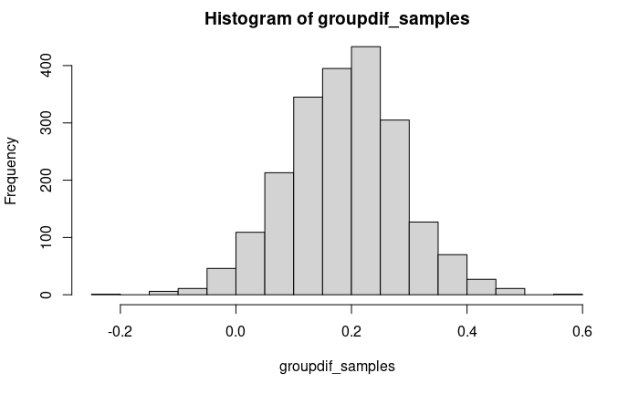

Now we can see the posterior probability. We can also examine the quantiles to help us interpret the probability.

```r
quantile(groupdif_samples, seq(0.05, 0.95, by=0.05))
```

```
        5%        10%        15%        20%        25%        30%        35%        40%        45%        50%        55%        60%        65%        70%        75%
0.02356858 0.06061863 0.08359025 0.10644580 0.12195650 0.13587290 0.15088155 0.16458240 0.18003180 0.19235400 0.20306475 0.21295500 0.22581820 0.23804640 0.25215600
       80%        85%        90%        95%
0.26511220 0.28379370 0.30766490 0.35247100
```

We can examine what the probability that it is above zero is.

```r
mean(groupdif_samples > 0)
```

```
[1] 0.9695238
```

With `brms`, we can also plot the estimated `sigma` spline.

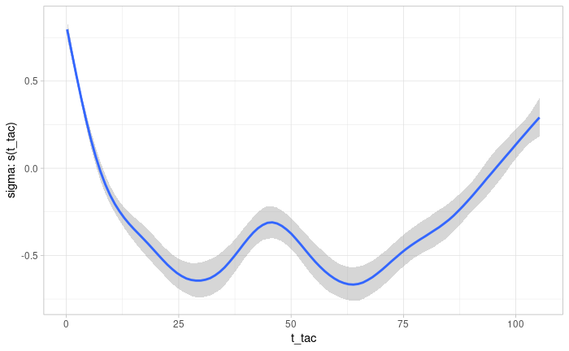

```r
conditional_smooths(brmsfit)
```